# Directional Change Ideas - NutNet

Evan Batzer

Jan 22, 2018

## Directional change in community composition based on treatment identity

### Background

- Global changes related to resource limtation are a well-studied phenomenon in ecology. Chronic nutrient enrichment, for example, is often expected to drive changes in community composition by altering competitive interactions.
- Many experiments that explore global change factors do so on relatively short timescales. However, these effects may not hold constant over time.
- Interactions between multiple drivers of resource limitation may be expected to produce nonlinear shifts in community dynamics that may contrast with those observed in short-term manipulative experiments.
- In particular, the strength of directional change in community composition is expected to be dependent on the nature of artificial resource enrichment (press vs. pulse) + other sources of environmental heterogeneity in a given system (e.g. Smith et al. 2009).
- When chronic nutrient deposition affects the primary axis of resource competition in community assembly, consistent directional change in community composition may be expected.
- However, when nutrient deposition interacts strongly with other drivers of resource limitation (such as normal environmental fluctuations, or extreme events, such as drought), community change may be strongly nonlinear/idiosyncratic

**Study sites**

NutNet has the advantage of (relatively) long-term datasets of community change across a number of sites in the United States. Within both California and across the Great Plains, there are sites containing nutrient enrichment treatments across a gradient of climatic conditions (precipitation/temperature)

- California Nutrient Network sites
- American perennial grassland sites? Konza/CdrCreek/etc.

**Some expectations:**

- All sites show changes in ANPP as a function of Nutrient enrichment + climate
- Sites with the greatest sensitivity to climate in ANPP will show the least directional change
- Sites with an annual life history (greater sensitivity / variability) will show less directional change
- In all sites, nutrient enrichment will cause segregation of communities with respect to one another over time
- Strength of nutrient enrichment in explaining multivariate dissimilaritiy between communities will depend on climate sensitivity

**Steps:**

1. Present characterization of site resource limitation and taxa **(Siddharth, would this be possible with some of your data?)**
2. Evaluate community directional change in response to nutrient enrichment over time.
3. Run ordination of multivariate community composition
4. PermDISP analysis of increasing dispersion over time
5. Evaluate significance of nutrient identity factors on community variance (CAP may be the best choice)

**Note:**

For this analysis, I only focused on 3 treatments (N, P, K) and controls. It may make sense to look at all factorial combinations, but the analysis for that is a little more challenging. How to define factor levels for treatment? All unique or additive?

### Constructing estimates of change in abundance-weighted diversity

The first analysis I wanted to conduct was to see if there’s a general trend in abundance-weighted diversity in these sites. I think of this as being the classic response to nutrient enrichment – a decrease in diversity that saturates over time as added nutrients no longer become limiting.

However, it doesn’t seem like there’s a consistent pattern across sites. In general, diversity is all over the place – the signal of nutrient enrichment isn’t very strong.

Note: In these figures, I’m using an exponentiated diversity index (sometimes referred to as Hill numbers). I’m not sure how familiar other folks are with this metric, but it’s very similar to Shannon diversity, with some advantages when comparing sites with big differences in total species richness.

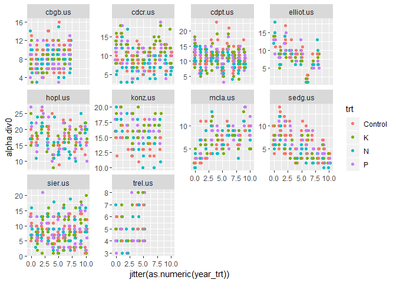

I was a little surprised by this result, so double-checked the shannon diversity richness values that are provided in the dropbox. The result seems about the same:

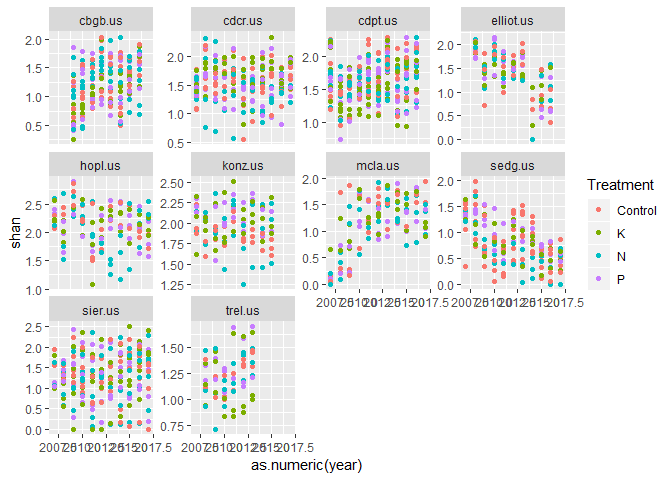

However, the year-to-year variation in this data is also striking, particularly among California sites. Sedgwick shows a persistent decrease in diversity over time, while McLaughlin seems to increase. Perhaps using a measure like the difference relative to control for each block would make more sense, or the ratio (or log-ratio) of diversity change would be more meaningful.

```r
# Elliot has one less control site
plot.sp.mat %>% group_by(site_code, block, trt) %>%
  dplyr::summarise(count = n()) %>%
  group_by(site_code, block) %>%
  filter(count[trt == "Control"] < max(count))
```

```
## # A tibble: 10 x 4
## # Groups:   site_code, block [1]
##    site_code block trt       count
##    <chr>     <int> <chr>     <int>
##  1 elliot.us     3 Control       8
##  2 elliot.us     3 Fence         9
##  3 elliot.us     3 K             9
##  4 elliot.us     3 N             9
##  5 elliot.us     3 NK            9
##  6 elliot.us     3 NP            9
##  7 elliot.us     3 NPK           9
##  8 elliot.us     3 NPK+Fence     9
##  9 elliot.us     3 P             9
## 10 elliot.us     3 PK            9
```

```r
plot.sp.mat %>%
  filter(site_code == "elliot.us") %>%
  group_by(year, block) %>%
  dplyr::summarise(count = n()) %>%
  arrange(count)
```

```
## # A tibble: 27 x 3
## # Groups:   year [9]
##     year block count
##    <int> <int> <int>
##  1  2014     1     8
##  2  2014     2     8
##  3  2014     3     9
##  4  2008     1    10
##  5  2008     2    10
##  6  2008     3    10
##  7  2009     1    10
##  8  2009     2    10
##  9  2009     3    10
## 10  2010     1    10
## # ... with 17 more rows
```

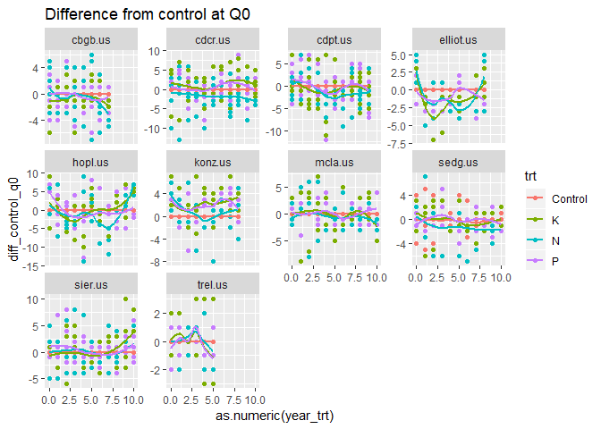

```r
control_change <- inner_join(cbind(plot.sp.mat[,1:6], alpha.div0) %>%
  group_by(site_code, year, block) %>%
  filter(!(site_code == "elliot.us" & year == "2014")) %>%
  mutate(diff_control_q0 = alpha.div0 - alpha.div0[trt == "Control"],
         diff_ratio_q0 = (alpha.div0 - alpha.div0[trt == "Control"]) / alpha.div0[trt == "Control"]),
  cbind(plot.sp.mat[,1:6], alpha.div1) %>%
  group_by(site_code, year, block) %>%
  filter(!(site_code == "elliot.us" & year == "2014")) %>%
  mutate(diff_control_q1 = alpha.div1 - alpha.div1[trt == "Control"],
         diff_ratio_q1 = (alpha.div1 - alpha.div1[trt == "Control"]) / alpha.div1[trt == "Control"])) %>% inner_join(
  cbind(plot.sp.mat[,1:6], alpha.div2) %>%
  group_by(site_code, year, block) %>%
  filter(!(site_code == "elliot.us" & year == "2014")) %>%
  mutate(diff_control_q2 = alpha.div2 - alpha.div2[trt == "Control"],
         diff_ratio_q2 = (alpha.div2 - alpha.div2[trt == "Control"]) / alpha.div2[trt == "Control"]))
control_change %>% filter(trt %in% trts) %>%
  ggplot(aes(x = as.numeric(year_trt),
           y = diff_control_q0,
           color = trt)) +
  facet_wrap(~site_code, scales = "free_y") +
  geom_point() +
  stat_smooth(se = FALSE) +
  ggtitle("Difference from control at Q0")
```

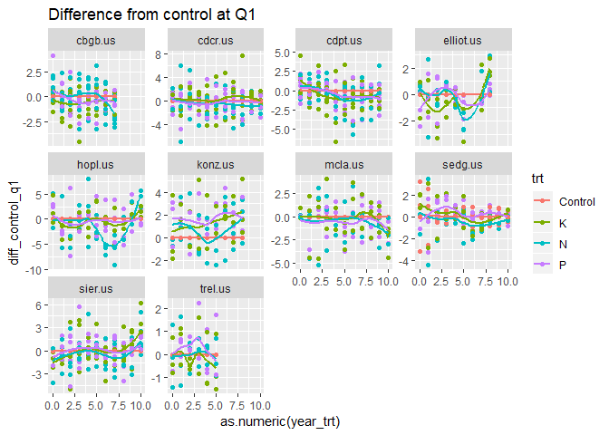

```r
control_change %>% filter(trt %in% trts) %>%
  ggplot(aes(x = as.numeric(year_trt),
           y = diff_control_q1,
           color = trt)) +
  facet_wrap(~site_code, scales = "free_y") +
  geom_point() +
  stat_smooth(se = FALSE) +
  ggtitle("Difference from control at Q1")
```

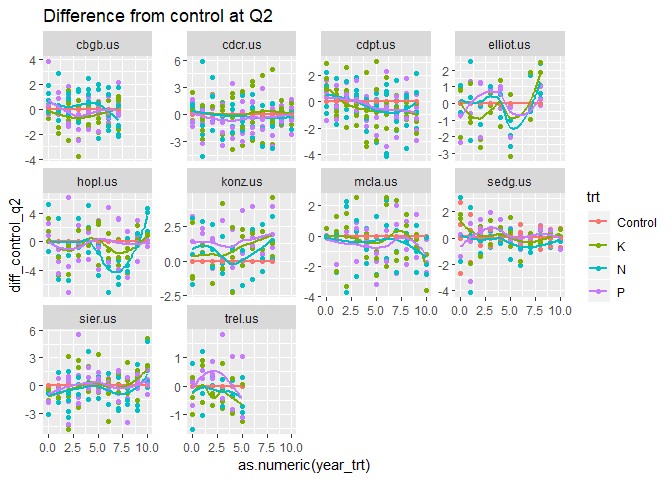

```r
control_change %>% filter(trt %in% trts) %>%
  ggplot(aes(x = as.numeric(year_trt),
           y = diff_control_q2,
           color = trt)) +
  facet_wrap(~site_code, scales = "free_y") +
  geom_point() +
  stat_smooth(se = FALSE) +
  ggtitle("Difference from control at Q2")
```

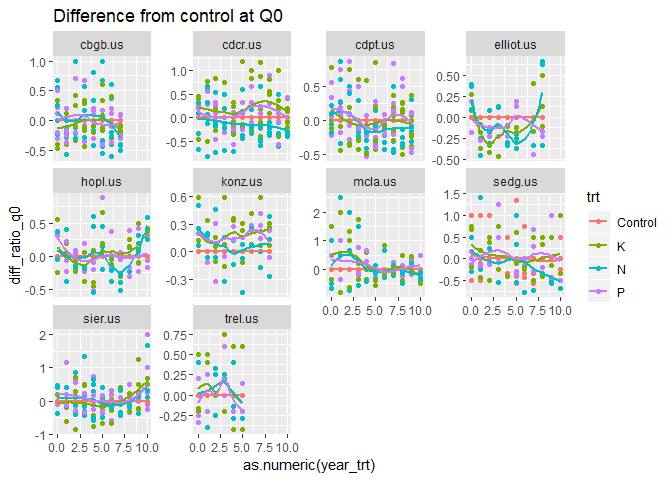

```r
control_change %>% filter(trt %in% trts) %>%
  ggplot(aes(x = as.numeric(year_trt),
           y = diff_ratio_q0,
           color = trt)) +
  facet_wrap(~site_code, scales = "free_y") +
  geom_point() +
  stat_smooth(se = FALSE) +
  ggtitle("Difference from control at Q0")
```

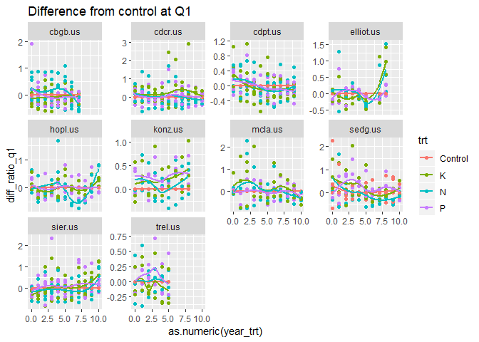

```r
control_change %>% filter(trt %in% trts) %>%
  ggplot(aes(x = as.numeric(year_trt),
           y = diff_ratio_q1,
           color = trt)) +
  facet_wrap(~site_code, scales = "free_y") +
  geom_point() +
  stat_smooth(se = FALSE) +
  ggtitle("Difference from control at Q1")
```

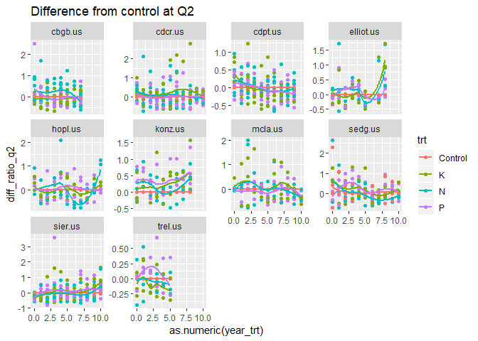

```r
control_change %>% filter(trt %in% trts) %>%
  ggplot(aes(x = as.numeric(year_trt),
           y = diff_ratio_q2,
           color = trt)) +
  facet_wrap(~site_code, scales = "free_y") +
  geom_point() +
  stat_smooth(se = FALSE) +
  ggtitle("Difference from control at Q2")
```

### Conducting analysis of temporal change

If there isn’t a great story associated wih diversity change, I think a focus on compositional change would be more compelling. From when we last talked about your work, I remember you talking about a project exploring the relationship between aridity index and the interaction between precipitation, temperature, and nutrient enrichment.

I think it would be really interesting to provide some context to compositional changes we might see. Comparing the relative strength of climate and nutrient enrichment effects might give us a sense of what resources are limiting in this system - if more arid systems experience greater influence of temperature and precipitation, we might anticipate that community change won’t follow a consistent directional trend, but fluctuate with seasonal variation.

My thought on how to incorporate this into analysis would be a relatively surface-level characterization, perhaps just reporting something like aridity index, MAT, and MAP for each site. I wouldn’t want to overlap with what you’ve been working on, but think this would be an opportunity to support our analysis with characterization of site resource limitation.

### Conducting analysis of temporal change

I think there are two key contrasts to be made in temporal analysis:

1. Annual vs perennially dominated sites.
2. Degree of climatic vs fertilization resource limitation.

Hypotheses:

1. Perenially-dominated sites will show stronger patterns of directional community change in response to nutrient enrichment.
2. Less arid sites will show stronger patterns of directional community change in response to nutrient enrichment.

As a first stab at this analysis, I used a modified version of the “rate_change_interval()” from the Codyn package. Rather than Euclidean distance, I opted for Bray-Curtis distance and a sqrt() transformed species matrix to reduce the influence of dominants. I don’t see any immediate issues with this approach, and it keeps analysis consistent with multivariate approaches (see next section).

In the following graphs, colored lines represent simple linear models to different treatments, faceted by site. Individual points reflect Bray-Curtis dissimilarity on the Y-axis and temporal lag on the X. Note: these treatments only focus on three treatments; N, P, and K.

From these figures, there seems to be a detectable N effect, *but only for perennial grassland sites*! Directional change is more or less the same among treatments in California.

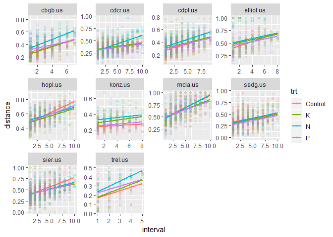

```
## Data: temp_ratechange_bray[temp_ratechange_bray$trt %in% trts, ]
## Models:
## m2: distance ~ interval + (1 | site_code) + (1 | site_code:block)
## m1: distance ~ interval + interval:trt + (1 + interval | site_code) +
## m1:     (1 | site_code:block)
##    Df     AIC     BIC logLik deviance  Chisq Chi Df Pr(>Chisq)
## m2  5 -7714.8 -7680.5 3862.4  -7724.8
## m1 10 -7932.2 -7863.6 3976.1  -7952.2 227.41      5  < 2.2e-16 ***
## ---
## Signif. codes:  0 '***' 0.001 '**' 0.01 '*' 0.05 '.' 0.1 ' ' 1
```

```
## Linear mixed model fit by maximum likelihood  ['lmerMod']
## Formula:
## distance ~ interval + interval:trt + (1 + interval | site_code) +
##     (1 | site_code:block)
##    Data: temp_ratechange_bray[temp_ratechange_bray$trt %in% trts, ]
##
##      AIC      BIC   logLik deviance df.resid
##  -7932.2  -7863.6   3976.1  -7952.2     7015
##
## Scaled residuals:
##     Min      1Q  Median      3Q     Max
## -4.2106 -0.6331 -0.0807  0.5663  4.6104
##
## Random effects:
##  Groups          Name        Variance  Std.Dev. Corr
##  site_code:block (Intercept) 0.0006716 0.025916
##  site_code       (Intercept) 0.0073321 0.085628
##                  interval    0.0000928 0.009633 0.31
##  Residual                    0.0185018 0.136021
## Number of obs: 7025, groups:  site_code:block, 40; site_code, 10
##
## Fixed effects:
##                Estimate Std. Error t value
## (Intercept)    0.327610   0.027640  11.853
## interval       0.027731   0.003256   8.517
## interval:trtK -0.002606   0.001041  -2.502
## interval:trtN  0.005951   0.001045   5.696
## interval:trtP -0.004265   0.001045  -4.080
##
## Correlation of Fixed Effects:
##             (Intr) intrvl intr:K intr:N
## interval     0.254
## intrvl:trtK  0.000 -0.153
## intrvl:trtN  0.000 -0.153  0.477
## intrvl:trtP  0.000 -0.152  0.477  0.475
```

### Dissimilarity relative to control:

```r
calc_dissimilarity <- function(x){

  # For each year in each block in each site

  # Calculate the dissimilarity matrix
  distmat <- vegdist(decostand(x[,-c(1:6)], method = "hellinger"), diag = TRUE)
  distmat <- data.frame(as.matrix(distmat))

  # Rename the distance matrix so that columns and rows are treatment names
  colnames(distmat) <- x$trt
  rownames(distmat) <- x$trt
  distmat$trt <- x$trt

  # Return the dataframe
  return(distmat)

}

x <- plot.sp.mat %>% group_by(site_code, block, trt, year) %>%
  filter(site_code == "mcla.us" & year == "2017" & block == 1)

calc_dissimilarity(x)
```

```
##                  NP        PK         P        NK       NPK     Fence
## NP        0.0000000 0.4911279 0.4909825 0.6585926 0.5487646 0.4595108
## PK        0.4911279 0.0000000 0.3910986 0.7550113 0.5242696 0.3689379
## P         0.4909825 0.3910986 0.0000000 0.5904094 0.4429670 0.3510366
## NK        0.6585926 0.7550113 0.5904094 0.0000000 0.4683139 0.5945803
## NPK       0.5487646 0.5242696 0.4429670 0.4683139 0.0000000 0.5135358
## Fence     0.4595108 0.3689379 0.3510366 0.5945803 0.5135358 0.0000000
## N         0.4898303 0.5729394 0.5080281 0.6767130 0.5530272 0.5175000
## K         0.5702094 0.4336031 0.4291776 0.6892117 0.4320632 0.2968958
## Control   0.5103572 0.4391218 0.2865165 0.5373020 0.2944705 0.3166702
## NPK+Fence 0.8800125 0.8510237 0.8218332 1.0000000 0.7270674 0.8204376
##                   N         K   Control NPK+Fence       trt
## NP        0.4898303 0.5702094 0.5103572 0.8800125        NP
## PK        0.5729394 0.4336031 0.4391218 0.8510237        PK
## P         0.5080281 0.4291776 0.2865165 0.8218332         P
## NK        0.6767130 0.6892117 0.5373020 1.0000000        NK
## NPK       0.5530272 0.4320632 0.2944705 0.7270674       NPK
## Fence     0.5175000 0.2968958 0.3166702 0.8204376     Fence
## N         0.0000000 0.5828063 0.4011637 0.4874380         N
## K         0.5828063 0.0000000 0.3503479 0.8237673         K
## Control   0.4011637 0.3503479 0.0000000 0.6538910   Control
## NPK+Fence 0.4874380 0.8237673 0.6538910 0.0000000 NPK+Fence
```

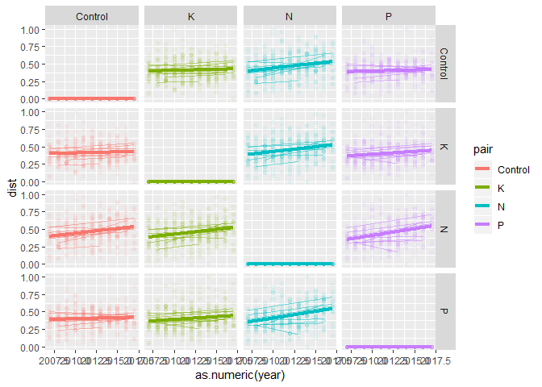

```r
pairwise_dist <- plot.sp.mat %>%
  group_by(site_code, block, year) %>%
  filter(trt %in% trts) %>%
  filter(site_code != "sedg.us") %>%
  do(calc_dissimilarity(.))

pairwise_dist %>% gather(key = "pair", value = "dist", -site_code, -block, -year, -trt) %>%
  ggplot(aes(x = as.numeric(year),
             y = dist,
             color = pair)) +
    geom_point(alpha = .05) +
  stat_smooth(method = "lm", size = 1.5, se = FALSE) +
  stat_smooth(aes(group = site_code), method = "lm", geom = "line", alpha = .5, se = FALSE) +
  facet_grid(trt ~ pair)
```

```r
ggsave("Figures/PairwiseDissimilarity.jpeg", height = 10, width = 15)
```